# Exploring Wine Quality

Dirk Kalmbach

July 2015

### Table of Content

1 Preperation

2 Exploratory Analysis

3 Final Plots and Summary

4 Reflection

5 References

Appendix

# 1 Preperation

```r
# Download csv-file to working directory:
URL <- "https://s3.amazonaws.com/udacity-hosted-downloads/ud651/wineQualityReds.csv"
download.file(URL, destfile = "./wine.csv", method="curl")

# Open data:
data = read.csv("wine.csv")
```

I begin with checking for missing values:

```r
anyNA(data)
```

```
## [1] FALSE
```

There are no missing values in the dataset. I can directly start with exploring the data:

# 2 Exploratory Analysis

**Note:** A detailed description of the variables can be found in the appendix.

```r
dim(data)
```

```
## [1] 1599   13
```

The dataset consists of 1599 cases with 13 variables per case (1 index, 11 independent, and 1 dependent variables). Every case *(i.e. every row in the dataset)* represents one particular red wine which was tasted and evaluated by wine experts. The result of this evaluation is stored in the variable `quality`.

As usual I start the exploration with printing out the first three rows of the dataset:

```r
head(data,3)
```

```
##   X fixed.acidity volatile.acidity citric.acid residual.sugar chlorides
## 1 1           7.4             0.70        0.00            1.9     0.076
## 2 2           7.8             0.88        0.00            2.6     0.098
## 3 3           7.8             0.76        0.04            2.3     0.092
##   free.sulfur.dioxide total.sulfur.dioxide density   pH sulphates alcohol
## 1                  11                   34  0.9978 3.51      0.56     9.4
## 2                  25                   67  0.9968 3.20      0.68     9.8
## 3                  15                   54  0.9970 3.26      0.65     9.8
##   quality
## 1       5
## 2       5
## 3       5
```

I continue with the so called **Five Number Summary** of the data, which shows the spread (minimium and maxiumun), the mean and the 2- and 3-quantiles:

```r
summary(data)
```

```
##        X        fixed.acidity   volatile.acidity  citric.acid
##  Min.   :   1   Min.   : 4.60   Min.   :0.120    Min.   :0.000
##  1st Qu.: 400   1st Qu.: 7.10   1st Qu.:0.390    1st Qu.:0.090
##  Median : 800   Median : 7.90   Median :0.520    Median :0.260
##  Mean   : 800   Mean   : 8.32   Mean   :0.528    Mean   :0.271
##  3rd Qu.:1200   3rd Qu.: 9.20   3rd Qu.:0.640    3rd Qu.:0.420
##  Max.   :1599   Max.   :15.90   Max.   :1.580    Max.   :1.000
##  residual.sugar    chlorides      free.sulfur.dioxide total.sulfur.dioxide
##  Min.   : 0.90   Min.   :0.0120   Min.   : 1.0        Min.   :  6.0
##  1st Qu.: 1.90   1st Qu.:0.0700   1st Qu.: 7.0        1st Qu.: 22.0
##  Median : 2.20   Median :0.0790   Median :14.0        Median : 38.0
##  Mean   : 2.54   Mean   :0.0875   Mean   :15.9        Mean   : 46.5
##  3rd Qu.: 2.60   3rd Qu.:0.0900   3rd Qu.:21.0        3rd Qu.: 62.0
##  Max.   :15.50   Max.   :0.6110   Max.   :72.0        Max.   :289.0
##     density            pH         sulphates        alcohol
##  Min.   :0.990   Min.   :2.74   Min.   :0.330   Min.   : 8.4
##  1st Qu.:0.996   1st Qu.:3.21   1st Qu.:0.550   1st Qu.: 9.5
##  Median :0.997   Median :3.31   Median :0.620   Median :10.2
##  Mean   :0.997   Mean   :3.31   Mean   :0.658   Mean   :10.4
##  3rd Qu.:0.998   3rd Qu.:3.40   3rd Qu.:0.730   3rd Qu.:11.1
##  Max.   :1.004   Max.   :4.01   Max.   :2.000   Max.   :14.9
##     quality
##  Min.   :3.00
##  1st Qu.:5.00
##  Median :6.00
##  Mean   :5.64
##  3rd Qu.:6.00
##  Max.   :8.00
```

Beside location parameters it is also useful to investigate the dispersion of the data. I thereforse continue with the standard deviation:

```r
sapply(data[2:13], sd)
```

```
##        fixed.acidity     volatile.acidity          citric.acid
##             1.741096             0.179060             0.194801
##       residual.sugar            chlorides  free.sulfur.dioxide
##             1.409928             0.047065            10.460157
## total.sulfur.dioxide              density                   pH
##            32.895324             0.001887             0.154386
##            sulphates              alcohol              quality
##             0.169507             1.065668             0.807569
```

Most statistical tests require normally distributed variables.  
The following graphs gives us more insights about the distribution of the variables:

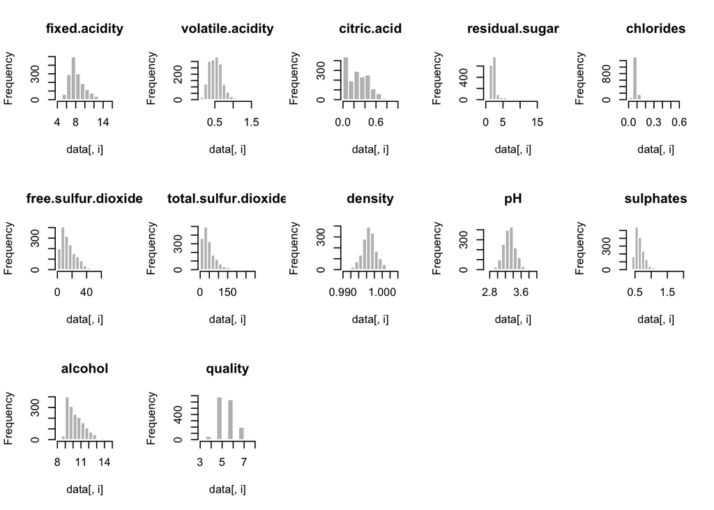

```r
par(mfrow=c(3, 5))
colnames <- dimnames(data)[[2]]
for (i in 2:13) {
    hist(data[,i], main=colnames[i], col="gray", border="white")
}
```

As we can see, only a few variables seem to be normally distributed (e.g.: `density` and `pH`), moreover most variables are right-skewed, and some variables have only a few states (e.g. `chlorides`).

The most important variable is `quality`. For a better evaluation wether this variable is normally distributed or not I print out a larger histogram:

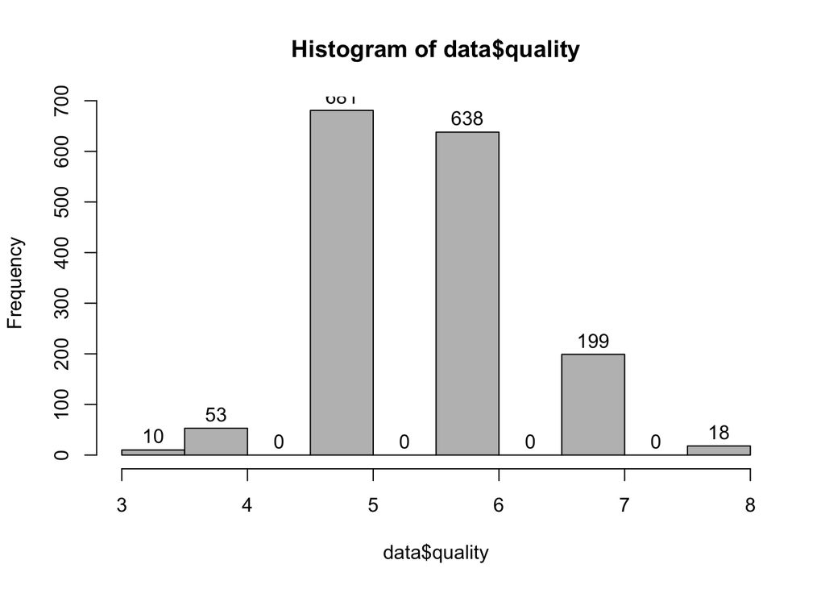

```r
hist(data$quality, col="gray", labels = TRUE)
```

From the histogram, we can see that most wines were evaluated with 5 or 6. Contrarily, very high and very low quality wines are not present. The following frequency table shows this more precisely:

```r
library(descr)
freq(data$quality, plot = FALSE)
```

```
## data$quality
##       Frequency  Percent
## 3            10   0.6254
## 4            53   3.3146
## 5           681  42.5891
## 6           638  39.8999
## 7           199  12.4453
## 8            18   1.1257
## Total      1599 100.0000
```

More than 80% of all wines are evaluated with a 5 or 6 on a 1-to-10-scale.

At this point, I am not sure wether I should assume the variable `quality` normally distributed. The **Shapiro-Wilk-Test** and the **Anderson-Darling-Test** which test against the assumption of normality however show a p-value smaller than 0.1:

```r
# Shapiro-Wilk-Test:
shapiro.test(data$quality)
```

```
##
##  Shapiro-Wilk normality test
##
## data:  data$quality
## W = 0.8576, p-value < 2.2e-16
```

```r
# Anderson-Darling-Test:
library(nortest)
ad.test(data$quality)
```

```
##
##  Anderson-Darling normality test
##
## data:  data$quality
## A = 110.6, p-value < 2.2e-16
```

According to these tests the null hypothetis that the sample came from a normally distributed population should be rejected. On the other side, the large sample size of n=`1599` together with the reasonably accurate bell curve shape indicates that we’re should be on the safe side with assuming `quality` as normally distributed.

However, it could make sense to summarize the variable. The red vertical line shows the average quality of all wines. I suggest to split the wines in two groups: wines below this line (quality scale of 5 and lower) and wines above this lines (quality scale of 6 and higher).

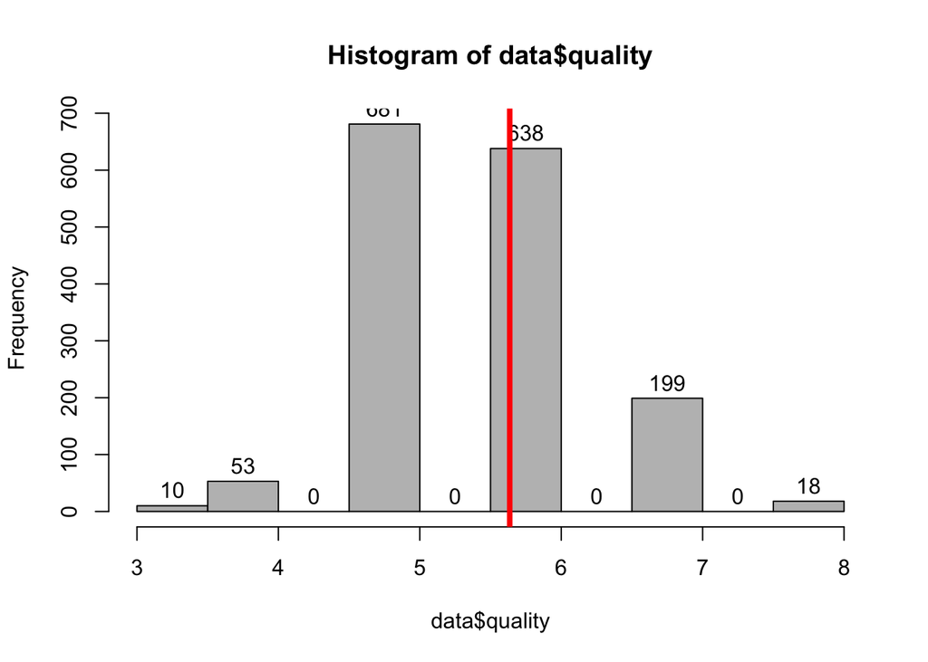

```r
hist(data$quality, col="gray", labels = TRUE)
abline(v=mean(data$quality), col="red", lwd=4)
```

The following code generates a new factor variable `qual_cat` with the values *low quality* and *high quality*:

```r
data$qual_cat <- rep(NA, nrow(data)) #create new column and fill with NA
data[data$quality <= 5, ][, "qual_cat"] <- "low Quality"
data[data$quality >= 6, ][, "qual_cat"] <- "high Quality"

table(data$qual_cat)
```

```
##
## high Quality  low Quality
##          855          744
```

It could be interesting to explore the independent variables referrring to the new created category `qual_cat`:

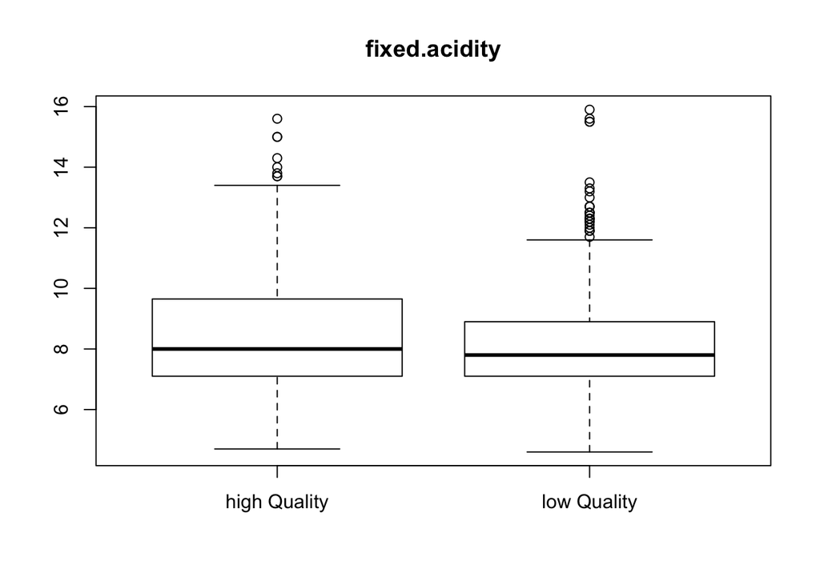

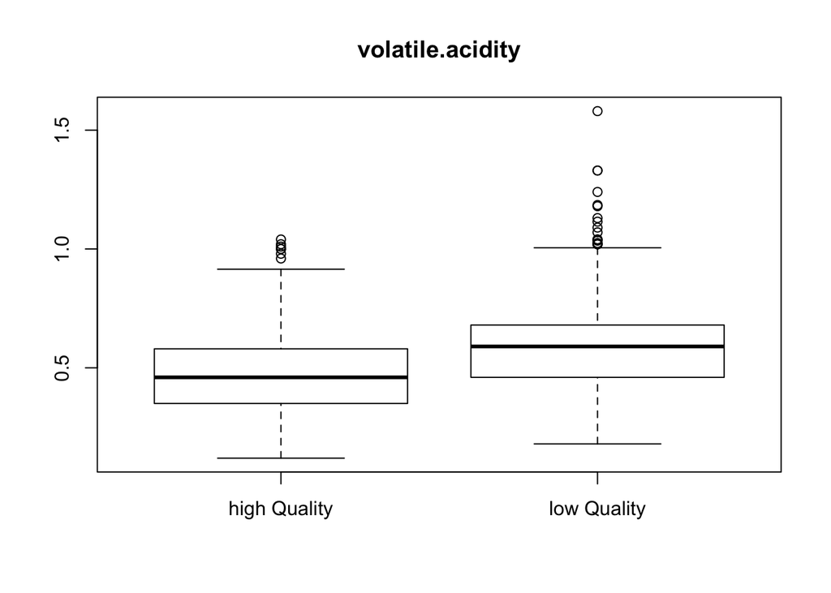

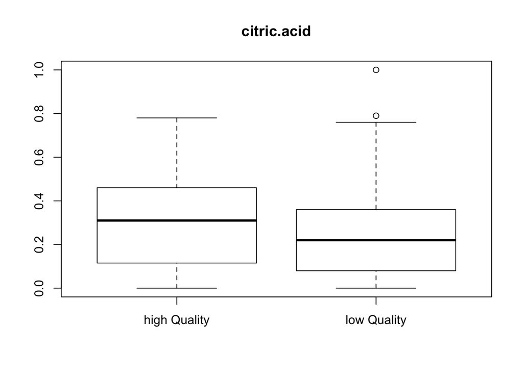

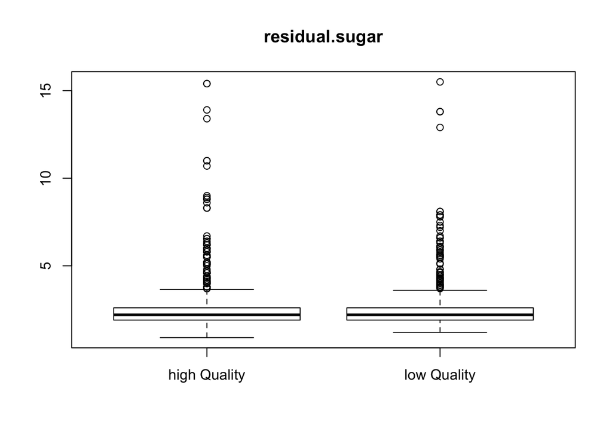

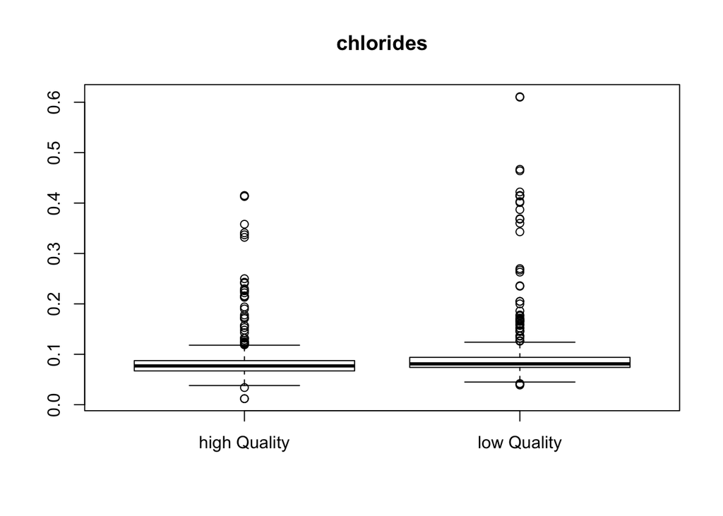

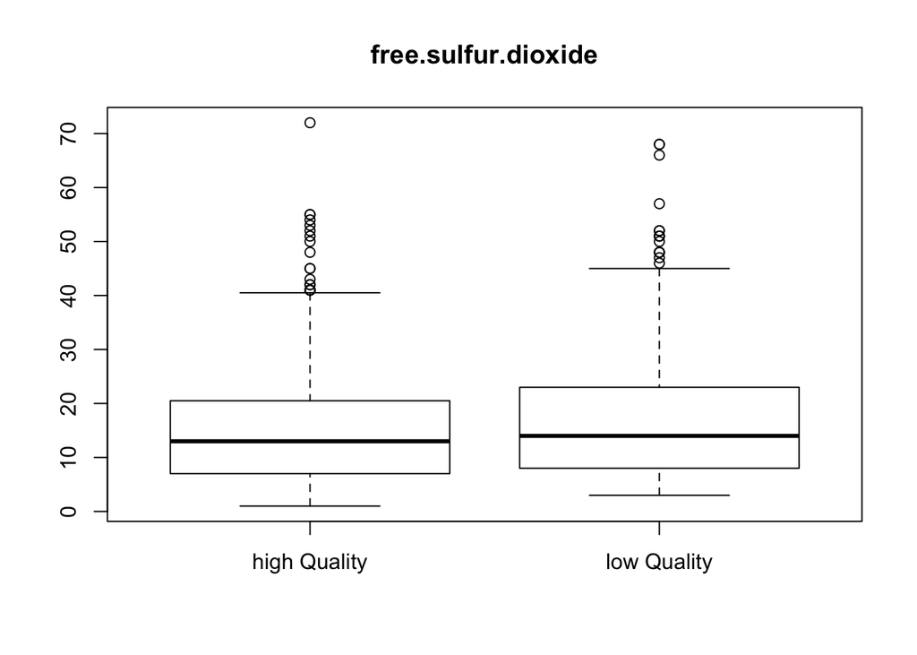

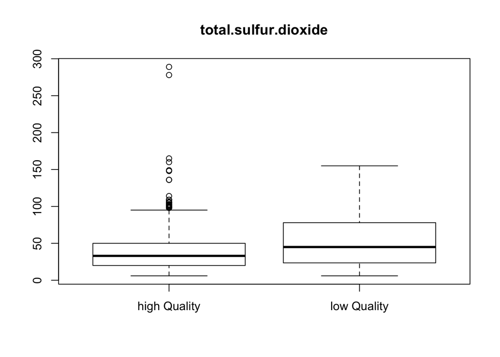

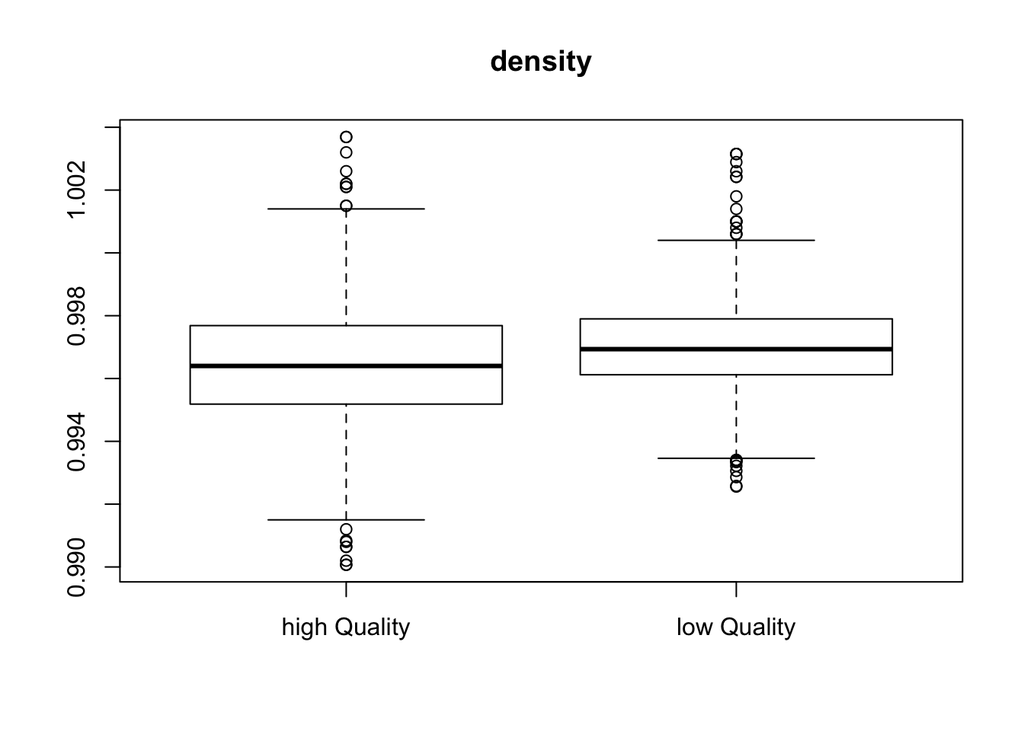

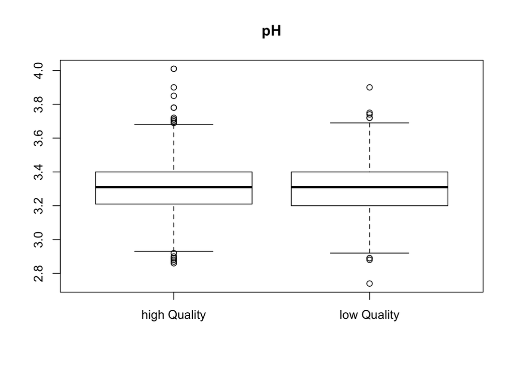

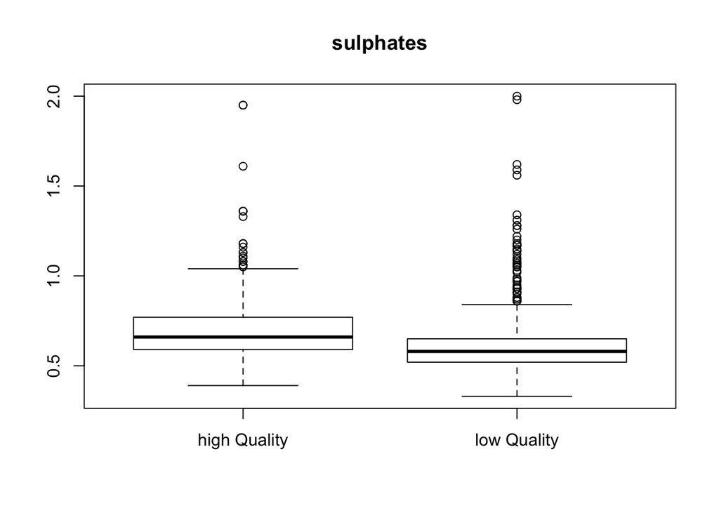

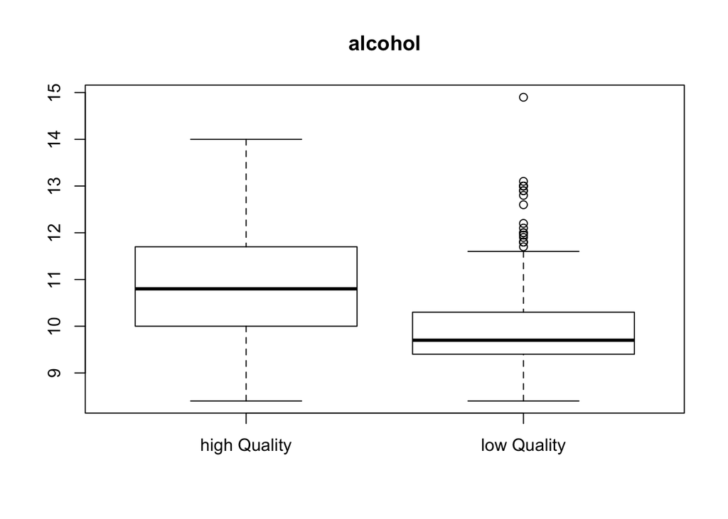

```r
#par(mfrow=c(3, 5))
colnames <- dimnames(data)[[2]]
for (i in 2:12) {
    boxplot(data[,i]~data$qual_cat, main=colnames[i])
}
```

We can see that esp. the variables `volatile.acidity` (= “amount of acetic acid in wine, which at too high of levels can lead to an unpleasant, vinegar taste”), `citric.acid`, and `alcohol` seems to have an influence on the wine quality. I.e. high quality red wines have less volatile acidity, more citric acid, and more alcohol.

I continue with checking how the independent variables might be influenced by each other:

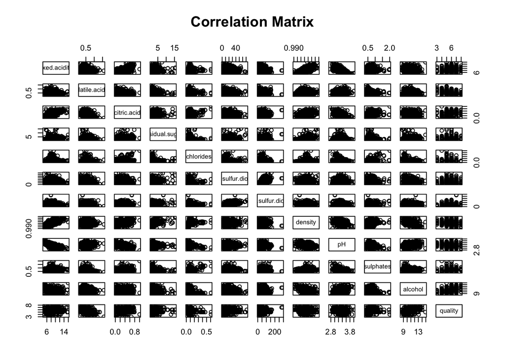

```r
# # Basic Scatterplot Matrix
# pairs(~fixed.acidity + volatile.acidity + volatile.acidity +
#             residual.sugar + chlorides + free.sulfur.dioxide + total.sulfur.dioxide +
#             density + pH + sulphates + alcohol,data=data,
#    main="Correlation Matrix")
pairs(data[,2:13], main="Correlation Matrix")
```

```r
# # More Advanced Scatterplot Matrix
# library(car)
# scatterplot.matrix(~fixed.acidity + volatile.acidity + volatile.acidity +
#             residual.sugar + chlorides + free.sulfur.dioxide + total.sulfur.dioxide +
#             density + pH + sulphates + alcohol,data=data, main="Correlation Matrix")
```

```r
library("psych")
corr_result <- corr.test(data[2:11])
corr_result$r
```

```
##                      fixed.acidity volatile.acidity citric.acid
## fixed.acidity              1.00000        -0.256131     0.67170
## volatile.acidity          -0.25613         1.000000    -0.55250
## citric.acid                0.67170        -0.552496     1.00000
## residual.sugar             0.11478         0.001918     0.14358
## chlorides                  0.09371         0.061298     0.20382
## free.sulfur.dioxide       -0.15379        -0.010504    -0.06098
## total.sulfur.dioxide      -0.11318         0.076470     0.03553
## density                    0.66805         0.022026     0.36495
## pH                        -0.68298         0.234937    -0.54190
## sulphates                  0.18301        -0.260987     0.31277
##                      residual.sugar chlorides free.sulfur.dioxide
## fixed.acidity              0.114777  0.093705           -0.153794
## volatile.acidity           0.001918  0.061298           -0.010504
## citric.acid                0.143577  0.203823           -0.060978
## residual.sugar             1.000000  0.055610            0.187049
## chlorides                  0.055610  1.000000            0.005562
## free.sulfur.dioxide        0.187049  0.005562            1.000000
## total.sulfur.dioxide       0.203028  0.047400            0.667666
## density                    0.355283  0.200632           -0.021946
## pH                        -0.085652 -0.265026            0.070377
## sulphates                  0.005527  0.371260            0.051658
##                      total.sulfur.dioxide  density       pH sulphates
## fixed.acidity                    -0.11318  0.66805 -0.68298  0.183006
## volatile.acidity                  0.07647  0.02203  0.23494 -0.260987
## citric.acid                       0.03553  0.36495 -0.54190  0.312770
## residual.sugar                    0.20303  0.35528 -0.08565  0.005527
## chlorides                         0.04740  0.20063 -0.26503  0.371260
## free.sulfur.dioxide               0.66767 -0.02195  0.07038  0.051658
## total.sulfur.dioxide              1.00000  0.07127 -0.06649  0.042947
## density                           0.07127  1.00000 -0.34170  0.148506
## pH                               -0.06649 -0.34170  1.00000 -0.196648
## sulphates                         0.04295  0.14851 -0.19665  1.000000
```

```r
corr_result$p
```

```
##                      fixed.acidity volatile.acidity citric.acid
## fixed.acidity            0.000e+00         0.000000   0.000e+00
## volatile.acidity         0.000e+00         0.000000   0.000e+00
## citric.acid              0.000e+00         0.000000   0.000e+00
## residual.sugar           4.199e-06         0.938917   8.084e-09
## chlorides                1.752e-04         0.014225   2.220e-16
## free.sulfur.dioxide      6.336e-10         0.674701   1.474e-02
## total.sulfur.dioxide     5.709e-06         0.002214   1.555e-01
## density                  0.000e+00         0.378755   0.000e+00
## pH                       0.000e+00         0.000000   0.000e+00
## sulphates                1.648e-13         0.000000   0.000e+00
##                      residual.sugar chlorides free.sulfur.dioxide
## fixed.acidity             8.819e-05 3.328e-03           1.521e-08
## volatile.acidity          1.000e+00 1.849e-01           1.000e+00
## citric.acid               1.778e-07 6.661e-15           1.849e-01
## residual.sugar            0.000e+00 2.879e-01           1.218e-12
## chlorides                 2.617e-02 0.000e+00           1.000e+00
## free.sulfur.dioxide       4.685e-14 8.241e-01           0.000e+00
## total.sulfur.dioxide      2.220e-16 5.809e-02           0.000e+00
## density                   0.000e+00 4.441e-16           3.805e-01
## pH                        6.066e-04 0.000e+00           4.870e-03
## sulphates                 8.252e-01 0.000e+00           3.888e-02
##                      total.sulfur.dioxide   density        pH sulphates
## fixed.acidity                   1.142e-04 0.000e+00 0.000e+00 4.119e-12
## volatile.acidity                3.764e-02 1.000e+00 0.000e+00 0.000e+00
## citric.acid                     1.000e+00 0.000e+00 0.000e+00 0.000e+00
## residual.sugar                  6.661e-15 0.000e+00 1.092e-02 1.000e+00
## chlorides                       5.228e-01 1.243e-14 0.000e+00 0.000e+00
## free.sulfur.dioxide             0.000e+00 1.000e+00 7.305e-02 3.888e-01
## total.sulfur.dioxide            0.000e+00 6.967e-02 1.095e-01 6.881e-01
## density                         4.354e-03 0.000e+00 0.000e+00 5.562e-08
## pH                              7.818e-03 0.000e+00 0.000e+00 5.995e-14
## sulphates                       8.602e-02 2.418e-09 2.220e-15 0.000e+00
```

The first table shows the correlation coefficients and the second table the significance values. We can see that some variables are correlated with each other.

As there does not exist an objective guideline for the interpretation of a correlation coefficient,<sup>2</sup> I suggest to consider correlations of more than 0.5 as high. I.e. variable pairs with correlation coefficients of more than 0.5 or less than -0.5. These are: - citric.acid <-> fixed.acidity - citric.acid <-> volatile.acidity - density <-> fixed.acidity - citric.acid <-> ph - fixed.acidity <-> ph - total.sulfur.dioxide <-> free.sulfur.dioxide

Citric.acid is correlated with three other variables. I suggest to keep citric.acid and total.sulfur.dioxide as the latter variable produced a higher R<sup>2</sup>:

```r
fit1 <- lm(quality ~ total.sulfur.dioxide, data=data)
fit2 <- lm(quality ~ free.sulfur.dioxide, data=data)
sprintf("R2 (total.sulfur.dioxide -> quality): %s", summary(fit1)$r.squared)
```

```
## [1] "R2 (total.sulfur.dioxide -> quality): 0.0342621169606877"
```

```r
sprintf("R2 (free.sulfur.dioxide -> quality): %s", summary(fit2)$r.squared)
```

```
## [1] "R2 (free.sulfur.dioxide -> quality): 0.00256603613553544"
```

**Note:** Here I used a simple linar regression model to evaluate the influence of `total.sulfur.dioxide` and `free.sulfur.dioxide` on wine quality. Although it is not appropriate to apply a linear regression model (because of the ordinal character of the dependant variable `quality`), I decided to use this kind of statistical method as this a quick and simple way to evaluate which variable has more influence.

The overall analysis in which I answer the question *which charecteristics have an influence on the wine quality* will be carried out with a logistic regression:

### Logistic Regression

Logistic regressions (logits) are used to model dichotomous outcome variables. Typical scenarios for logit-models are linear regressions in which the dependant variable is not metric. In the logit model the *log odds* of the outcome is modeled as a linear combination of the predictor variables. Log odds are an alternate way of expressing probabilities, log odds are the log of the odds ratio.<sup>3</sup>

I start with converting the newly build factor variable `qual_cat` into a dichotomous variable:

```r
# Convert qual_cat in binary variable (0="low quality""; 1="high quality"):
y <- ifelse(data$qual_cat=="high Quality", 1, 0)
table(y)
```

```
## y
##   0   1
## 744 855
```

Wines of high (low) quality are now labeled with 1 (0).

Next I call the logit model:

```r
# Call logistic regression:
# mylogit <- glm( y ~ fixed.acidity + volatile.acidity + volatile.acidity + citric.acid +
#             residual.sugar + chlorides + free.sulfur.dioxide + total.sulfur.dioxide +
#             density + pH + sulphates + alcohol, data = data, family = "binomial")
mylogit <- glm( y ~ volatile.acidity + citric.acid +
            residual.sugar + chlorides + total.sulfur.dioxide +
            sulphates + alcohol, data = data, family = "binomial")
# Print results
summary(mylogit)
```

```
##
## Call:
## glm(formula = y ~ volatile.acidity + citric.acid + residual.sugar +
##     chlorides + total.sulfur.dioxide + sulphates + alcohol, family = "binomial",
##     data = data)
##
## Deviance Residuals:
##    Min      1Q  Median      3Q     Max
## -3.135  -0.855   0.320   0.859   2.301
##
## Coefficients:
##                      Estimate Std. Error z value Pr(>|z|)
## (Intercept)          -7.99561    0.81848   -9.77  < 2e-16 ***
## volatile.acidity     -3.33332    0.45466   -7.33  2.3e-13 ***
## citric.acid          -0.60136    0.40093   -1.50   0.1336
## residual.sugar        0.04891    0.04470    1.09   0.2739
## chlorides            -4.14268    1.47283   -2.81   0.0049 **
## total.sulfur.dioxide -0.01247    0.00202   -6.17  6.6e-10 ***
## sulphates             2.80513    0.43809    6.40  1.5e-10 ***
## alcohol               0.87606    0.07135   12.28  < 2e-16 ***
## ---
## Signif. codes:  0 '***' 0.001 '**' 0.01 '*' 0.05 '.' 0.1 ' ' 1
##
## (Dispersion parameter for binomial family taken to be 1)
##
##     Null deviance: 2209.0  on 1598  degrees of freedom
## Residual deviance: 1670.7  on 1591  degrees of freedom
## AIC: 1687
##
## Number of Fisher Scoring iterations: 4
```

The matrix shows the logistic regression coefficients. These are the change in the log odds of the outcome variable `qual_cat` for a one unit increase in the predictor variable. The exponential function of this gives us the **odd ratios** which are easier to interpret:

```r
exp(cbind(OR = coef(mylogit), confint(mylogit)))
```

```
##                             OR     2.5 %    97.5 %
## (Intercept)          3.369e-04 0.0000664  0.001646
## volatile.acidity     3.567e-02 0.0144299  0.085862
## citric.acid          5.481e-01 0.2489936  1.200110
## residual.sugar       1.050e+00 0.9610567  1.146004
## chlorides            1.588e-02 0.0008202  0.270856
## total.sulfur.dioxide 9.876e-01 0.9836514  0.991481
## sulphates            1.653e+01 7.1438381 39.802301
## alcohol              2.401e+00 2.0930772  2.768992
```

Finally, let’s check how well the model fit:

```r
chi <- with(mylogit, null.deviance - deviance)
df <- with(mylogit, df.null - df.residual)
p_value <- with(mylogit, pchisq(null.deviance - deviance, df.null - df.residual,
                                lower.tail = FALSE))
sprintf("Test Statistic (chi2): %s", chi)
```

```
## [1] "Test Statistic (chi2): 538.304915401857"
```

```r
sprintf("Degrees of Freedom: %s", df)
```

```
## [1] "Degrees of Freedom: 7"
```

```r
sprintf("P-value: %s", p_value)
```

```
## [1] "P-value: 4.63479040986253e-112"
```

The chi-square of 538.3049 with 7 degrees of freedom and an associated p-value of less than 0.001 tells us that our model as a whole fits significantly better than an empty model.

# 3 Final Plots and Summary

Again, I start with plotting the distribution of the most important variable in the dataset, the wine quality:

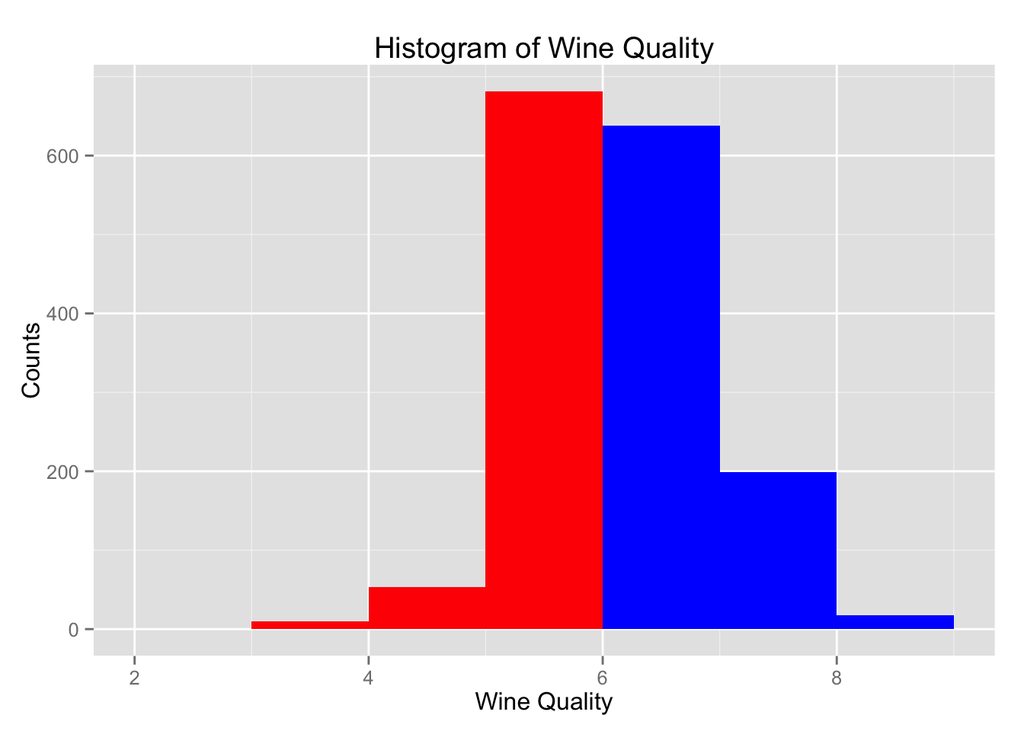

```r
library(ggplot2)
ggplot(data, aes(x=quality)) +
    geom_histogram(binwidth=1,data=subset(data,quality<6), fill="red") +
    geom_histogram(binwidth=1,data=subset(data,quality>5), fill="blue") +
    xlab('Wine Quality') +
    ylab('Counts') +
    ggtitle('Histogram of Wine Quality')
```

According to the low range of the variable `quality`, I decided throughout the analysis to split the dataset in two groups: wines of low quality (marked red) and wines of high quality (marked as blue).

After this, we can easily see how both groups differ:

```r
#Create means of variables for each quality category:
features <- c("volatile.acidity", "citric.acid", "residual.sugar",
              "chlorides", "sulphates", "total.sulfur.dioxide", "alcohol")
features_translated <- c("acetic acid", "citric acid", "residual sugar",
                     "sodium chloride", "sulphates", "total sulfur dioxide", "alcohol")
mean_lowQual<-apply(data[data$qual_cat=="low Quality",][,features],2,mean)
mean_highQual<-apply(data[data$qual_cat=="high Quality",][,features],2,mean)

#Merge both rows:
means <- rbind(mean_lowQual,mean_highQual)
means
```

```
##               volatile.acidity citric.acid residual.sugar chlorides
## mean_lowQual            0.5895      0.2378          2.542   0.09299
## mean_highQual           0.4741      0.2999          2.536   0.08266
##               sulphates total.sulfur.dioxide alcohol
## mean_lowQual     0.6185                54.65   9.926
## mean_highQual    0.6926                39.35  10.855
```

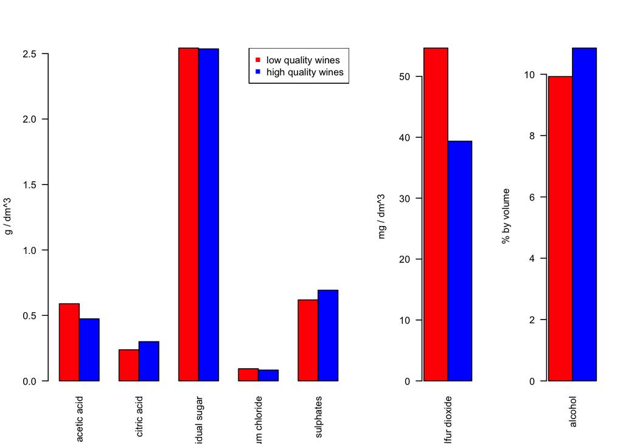

```r
# Create barplot:
layout( matrix(c(1,2,3),1,3), widths=c(3,1), heights=c(1,2))

barplot(means[,1:5],beside=T,
        col = c("red", "blue"), ylab = "g / dm^3",
        names = features_translated[1:5], las=2)

legend("topright", legend = c("low quality wines","high quality wines"),
       pch=15, col = c("red", "blue") )

barplot(means[,6], width=1,beside=T,
        col = c("red", "blue"), ylab = "mg / dm^3",
        names = features_translated[6], las=2, space=0)

barplot(means[,7], width=1,beside=T,
        col = c("red", "blue"), ylab = "% by volume",
        names = features_translated[7],las=2, space=0)
```

Sugar for example does not have an influence on wine quality. Alcohol, acid and sulphates on the other side does have an influence on wine quality: high quality wines contain more alcohol, citric acid and sulphates on average.

However, the dataset contains some outliers:

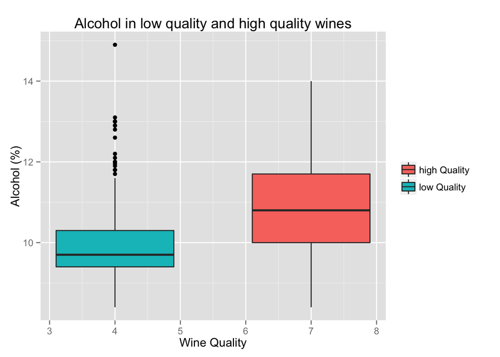

```r
library(ggplot2)
ggplot(data=data, aes(x=quality, y=alcohol, fill=qual_cat)) +
    geom_boxplot() + ggtitle("Alcohol in low quality and high quality wines") +
    xlab('Wine Quality') + ylab("Alcohol (%)") +
    theme(legend.title=element_blank())
```

High percentage of alcohol does not necessarily guarantee high wine quality. Some low quality wines have alcohol strengths of more than 12%.

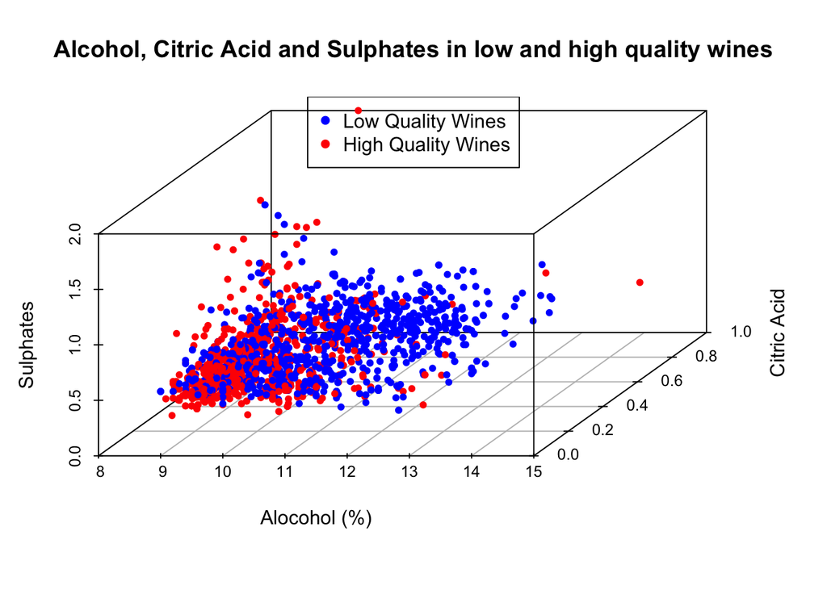

```r
library(scatterplot3d)
# create column indicating point color
data$pcolor[data$qual_cat=="low Quality"] <- "red"
data$pcolor[data$qual_cat=="high Quality"] <- "blue"

with(data, {
    scatterplot3d(alcohol, citric.acid, sulphates,
                  color=pcolor, pch=20,
                  xlab="Alocohol (%)",
                  ylab="Citric Acid",
                  zlab="Sulphates")
    legend(x="top", legend = c("Low Quality Wines","High Quality Wines"), col=c("blue","red"), pch=16)
    title("Alcohol, Citric Acid and Sulphates in low and high quality wines")
})
```

# 4 Reflection

Throughout the analysis I raised the question how accurate and objective the wine experts validations are. Did all wine experts come to the same test result? Unfortunately the dataset does not contain a variable which identifies the test person. A possible test design for future studies could be to investigate if clusters of wine experts exist which evaluate in a similar way. Those clusters could be described by socio- or psychodemographic variables. E.g.: do younger wine experts evaluate different compared to older experts?

# 5 References

1. P. Cortez, A. Cerdeira, F. Almeida, T. Matos and J. Reis. Modeling wine preferences by data mining from physicochemical properties. In: *Decision Support Systems*, Elsevier, 47(4):547-553. ISSN: 0167-9236.
2. Interpretation of the size of a correlation (2015). In: *Wikipedia.* Retrieved: June 24, 2015, from [Wikipedia](https://en.wikipedia.org/wiki/Pearson_product-moment_correlation_coefficient#Interpretation_of_the_size_of_a_correlation).
3. R Data Analysis Examples: Logit Regression (n.d.). In: *Institute for Digital Research and Education (idre)* Retrieved: June 24, 2015, from [www.ats.ucla.edu](http://www.ats.ucla.edu/stat/r/dae/logit.htm).

# Appendix

## Variable Description

| Variable | Description |
| --- | --- |
| fixed acidity | most acids involved with wine or fixed or nonvolatile (do not evaporate readily) |
| volatile acidity | the amount of acetic acid in wine, which at too high of levels can lead to an unpleasant, vinegar taste |
| citric acid | found in small quantities, citric acid can add ‘freshness’ and flavor to wines |
| residual sugar | the amount of sugar remaining after fermentation stops, it’s rare to find wines with less than 1 gram/liter and wines with greater than 45 grams/liter are considered sweet |
| chlorides | the amount of salt in the wine |
| free sulfur dioxide | the free form of SO2 exists in equilibrium between molecular SO2 (as a dissolved gas) and bisulfite ion; it prevents microbial growth and the oxidation of wine |
| total sulfur dioxide | amount of free and bound forms of S02; in low concentrations, SO2 is mostly undetectable in wine, but at free SO2 concentrations over 50 ppm, SO2 becomes evident in the nose and taste of wine |
| density | the density of water is close to that of water depending on the percent alcohol and sugar content |
| pH | describes how acidic or basic a wine is on a scale from 0 (very acidic) to 14 (very basic); most wines are between 3-4 on the pH scale |
| sulphates | a wine additive which can contribute to sulfur dioxide gas (S02) levels, wich acts as an antimicrobial and antioxidant |
| alcohol | the percent alcohol content of the wine |
| quality | Ouput Variable (score between 0 and 10) |

## Multiple Regression

```r
model1<-lm(quality ~
             fixed.acidity +
             volatile.acidity +
             citric.acid +
             residual.sugar +
             chlorides +
             free.sulfur.dioxide +
             total.sulfur.dioxide +
             density  +
             pH +
             sulphates +
             alcohol, data=data )
summary(model1)
```

```
##
## Call:
## lm(formula = quality ~ fixed.acidity + volatile.acidity + citric.acid +
##     residual.sugar + chlorides + free.sulfur.dioxide + total.sulfur.dioxide +
##     density + pH + sulphates + alcohol, data = data)
##
## Residuals:
##    Min     1Q Median     3Q    Max
## -2.689 -0.366 -0.047  0.452  2.025
##
## Coefficients:
##                       Estimate Std. Error t value Pr(>|t|)
## (Intercept)           2.20e+01   2.12e+01    1.04    0.300
## fixed.acidity         2.50e-02   2.59e-02    0.96    0.336
## volatile.acidity     -1.08e+00   1.21e-01   -8.95  < 2e-16 ***
## citric.acid          -1.83e-01   1.47e-01   -1.24    0.215
## residual.sugar        1.63e-02   1.50e-02    1.09    0.276
## chlorides            -1.87e+00   4.19e-01   -4.47  8.4e-06 ***
## free.sulfur.dioxide   4.36e-03   2.17e-03    2.01    0.045 *
## total.sulfur.dioxide -3.27e-03   7.29e-04   -4.48  8.0e-06 ***
## density              -1.79e+01   2.16e+01   -0.83    0.409
## pH                   -4.14e-01   1.92e-01   -2.16    0.031 *
## sulphates             9.16e-01   1.14e-01    8.01  2.1e-15 ***
## alcohol               2.76e-01   2.65e-02   10.43  < 2e-16 ***
## ---
## Signif. codes:  0 '***' 0.001 '**' 0.01 '*' 0.05 '.' 0.1 ' ' 1
##
## Residual standard error: 0.648 on 1587 degrees of freedom
## Multiple R-squared:  0.361,  Adjusted R-squared:  0.356
## F-statistic: 81.3 on 11 and 1587 DF,  p-value: <2e-16
```

```r
model2 = update(model1, .~.-citric.acid, .~.-residual.sugar)
summary(model2)
```

```
##
## Call:
## lm(formula = quality ~ fixed.acidity + volatile.acidity + residual.sugar +
##     chlorides + free.sulfur.dioxide + total.sulfur.dioxide +
##     density + pH + sulphates + alcohol, data = data)
##
## Residuals:
##     Min      1Q  Median      3Q     Max
## -2.6896 -0.3697 -0.0464  0.4563  2.0247
##
## Coefficients:
##                       Estimate Std. Error t value Pr(>|t|)
## (Intercept)           2.22e+01   2.12e+01    1.05    0.294
## fixed.acidity         1.43e-02   2.45e-02    0.58    0.560
## volatile.acidity     -1.00e+00   1.02e-01   -9.81  < 2e-16 ***
## residual.sugar        1.53e-02   1.50e-02    1.02    0.306
## chlorides            -2.01e+00   4.05e-01   -4.97  7.3e-07 ***
## free.sulfur.dioxide   4.80e-03   2.14e-03    2.24    0.025 *
## total.sulfur.dioxide -3.50e-03   7.03e-04   -4.99  6.8e-07 ***
## density              -1.81e+01   2.16e+01   -0.84    0.403
## pH                   -4.06e-01   1.92e-01   -2.12    0.034 *
## sulphates             9.13e-01   1.14e-01    7.98  2.7e-15 ***
## alcohol               2.71e-01   2.62e-02   10.36  < 2e-16 ***
## ---
## Signif. codes:  0 '***' 0.001 '**' 0.01 '*' 0.05 '.' 0.1 ' ' 1
##
## Residual standard error: 0.648 on 1588 degrees of freedom
## Multiple R-squared:  0.36,   Adjusted R-squared:  0.356
## F-statistic: 89.3 on 10 and 1588 DF,  p-value: <2e-16
```

```r
model3 = update(model2, .~.-density)
summary(model3)
```

```
##
## Call:
## lm(formula = quality ~ fixed.acidity + volatile.acidity + residual.sugar +
##     chlorides + free.sulfur.dioxide + total.sulfur.dioxide +
##     pH + sulphates + alcohol, data = data)
##
## Residuals:
##     Min      1Q  Median      3Q     Max
## -2.6724 -0.3681 -0.0479  0.4663  2.0388
##
## Coefficients:
##                      Estimate Std. Error t value Pr(>|t|)
## (Intercept)           4.50087    0.61152    7.36  2.9e-13 ***
## fixed.acidity        -0.00286    0.01342   -0.21   0.8310
## volatile.acidity     -1.01571    0.10118  -10.04  < 2e-16 ***
## residual.sugar        0.00785    0.01202    0.65   0.5137
## chlorides            -2.04511    0.40246   -5.08  4.2e-07 ***
## free.sulfur.dioxide   0.00496    0.00213    2.32   0.0203 *
## total.sulfur.dioxide -0.00355    0.00070   -5.07  4.3e-07 ***
## pH                   -0.49727    0.15704   -3.17   0.0016 **
## sulphates             0.88880    0.11073    8.03  1.9e-15 ***
## alcohol               0.28802    0.01692   17.02  < 2e-16 ***
## ---
## Signif. codes:  0 '***' 0.001 '**' 0.01 '*' 0.05 '.' 0.1 ' ' 1
##
## Residual standard error: 0.648 on 1589 degrees of freedom
## Multiple R-squared:  0.36,   Adjusted R-squared:  0.356
## F-statistic: 99.2 on 9 and 1589 DF,  p-value: <2e-16
```

```r
# Stepwise:
step(model1, direction="backward")
```

```
## Start:  AIC=-1375
## quality ~ fixed.acidity + volatile.acidity + citric.acid + residual.sugar +
##     chlorides + free.sulfur.dioxide + total.sulfur.dioxide +
##     density + pH + sulphates + alcohol
##
##                        Df Sum of Sq RSS   AIC
## - density               1       0.3 667 -1377
## - fixed.acidity         1       0.4 667 -1377
## - residual.sugar        1       0.5 667 -1376
## - citric.acid           1       0.6 667 -1376
## <none>                              666 -1375
## - free.sulfur.dioxide   1       1.7 668 -1373
## - pH                    1       2.0 668 -1373
## - chlorides             1       8.4 675 -1357
## - total.sulfur.dioxide  1       8.4 675 -1357
## - sulphates             1      27.0 693 -1314
## - volatile.acidity      1      33.6 700 -1299
## - alcohol               1      45.7 712 -1271
##
## Step:  AIC=-1377
## quality ~ fixed.acidity + volatile.acidity + citric.acid + residual.sugar +
##     chlorides + free.sulfur.dioxide + total.sulfur.dioxide +
##     pH + sulphates + alcohol
##
##                        Df Sum of Sq RSS   AIC
## - fixed.acidity         1       0.1 667 -1379
## - residual.sugar        1       0.2 667 -1378
## - citric.acid           1       0.7 667 -1377
## <none>                              667 -1377
## - free.sulfur.dioxide   1       1.8 669 -1374
## - pH                    1       4.3 671 -1368
## - total.sulfur.dioxide  1       8.7 675 -1358
## - chlorides             1       8.8 675 -1358
## - sulphates             1      27.3 694 -1315
## - volatile.acidity      1      35.0 702 -1297
## - alcohol               1     119.7 786 -1115
##
## Step:  AIC=-1379
## quality ~ volatile.acidity + citric.acid + residual.sugar + chlorides +
##     free.sulfur.dioxide + total.sulfur.dioxide + pH + sulphates +
```

[output cut: 27 more lines]

```
## - alcohol               1     122.7 790 -1112
##
## Step:  AIC=-1381
## quality ~ volatile.acidity + chlorides + free.sulfur.dioxide +
##     total.sulfur.dioxide + pH + sulphates + alcohol
##
##                        Df Sum of Sq RSS   AIC
## <none>                              668 -1381
## - free.sulfur.dioxide   1       2.4 670 -1377
## - pH                    1       7.1 675 -1366
## - total.sulfur.dioxide  1      10.8 678 -1357
## - chlorides             1      10.8 678 -1357
## - sulphates             1      27.1 695 -1319
## - volatile.acidity      1      42.3 710 -1285
## - alcohol               1     124.5 792 -1109
```

```
##
## Call:
## lm(formula = quality ~ volatile.acidity + chlorides + free.sulfur.dioxide +
##     total.sulfur.dioxide + pH + sulphates + alcohol, data = data)
##
## Coefficients:
##          (Intercept)      volatile.acidity             chlorides
##              4.43010              -1.01275              -2.01781
##  free.sulfur.dioxide  total.sulfur.dioxide                    pH
##              0.00508              -0.00348              -0.48266
##            sulphates               alcohol
##              0.88267               0.28930
```

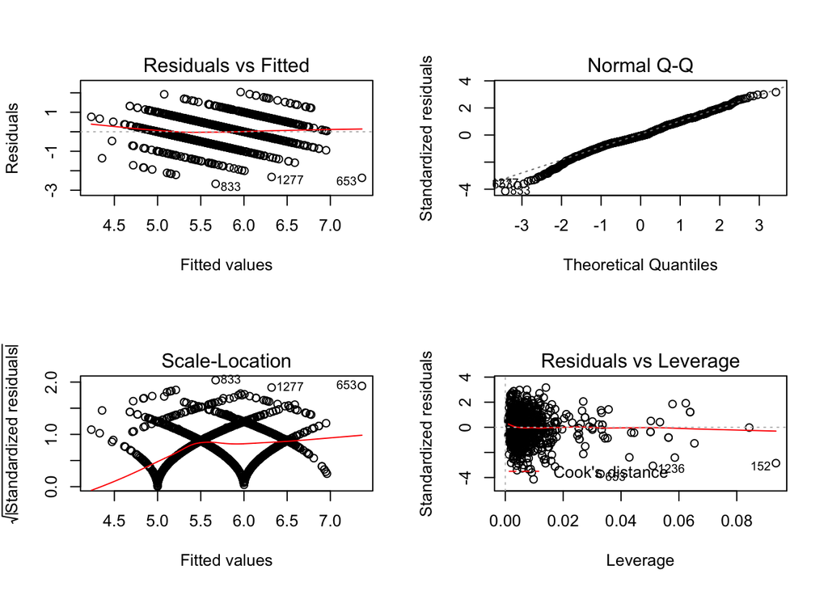

```r
# Regression Diagnostics:
par(mfrow=c(2,2))                    # visualize four graphs at once
plot(model3)
```

```r
par(mfrow=c(1,1))                    # reset the graphics defaults
```